# Assignment 3 - Amirbekyan, Mari

# Dataset Description: U.S. Bilateral Trade in Poultry Products

This dataset contains bilateral international trade data for the United States as the reporter country, focusing on the commodity classified under “**meat and edible offal**” of poultry, traded in fresh, chilled, or frozen form.

The dataset includes poultry products, covering common cuts and parts such as breasts, thighs, wings, livers, hearts, and gizzards. It excludes live poultry and processed poultry products.

Trade flows are reported with all countries as partners, meaning the data capture U.S. poultry trade with every trading partner (countries) worldwide. The dataset includes:

- Imports: Poultry products entering the United States from foreign suppliers (e.g., frozen chicken from Brazil or Canada).
- Exports: Poultry products shipped from the United States to international markets (e.g., U.S. poultry exports to Mexico or Asian countries).

# Data Source:

The dataset is obtained from the UN Comtrade database, an open-access repository of official international trade statistics compiled from customs data reported by over 150 countries. Key variables include trade values (USD) and quantities (kilograms), reflecting officially reported bilateral trade flows between the United States and its trading partners.

# General directions

1. For each question, you are encouraged to create a chunk below it, and fully develop the code that creates your answer.
2. You are encouraged to use wrangling functions from the packages `dplyr` and `tidyr`, and plotting functions from the package `ggplot2`.
3. You are encouraged to the the pipe operator (`%>%` or `|>`) to pipe wrangling steps together.
4. For each question, after showing your code and output (be it numerical or graphical), you also need to provide a written sentence of your answer. Just showing code output is not sufficient for full points.
5. As part of the initial wrangling, you are expected to:

Transform the `qty` column from kg to Mg  
Select only columns that are useful to answer the questions.

6. Check out the following cheatsheets to give you some ideas on wrangling and plotting:

**ggplot2**: https://posit.co/wp-content/uploads/2022/10/data-visualization-1.pdf  
**dplyr**: https://rstudio.github.io/cheatsheets/data-transformation.pdf

## Dataset

```r
library(readxl) # to read excel files
library(janitor) # to clean data
library(dplyr) # wrangling
library(tidyr) # wrangling
library(readr) # to export csv
library(tidyverse) # to wrangle the data
library(ggplot2)
```

Setting up the data; Changing the units from Kg to Mg

```r
getwd()
```

```
[1] "/Users/mariamirbekyan/Documents/Higher Education/UGA Masters/Spring 2026/Data Science and Statistical Programming/CRSS8030_Assignment_Wrangling/Code"
```

```r
poultrydata <- read_csv("../data/03_assignment_data.csv")
view(poultrydata)

poultrydata_Mg <- mutate(poultrydata,
                         qty_in_Mg = qty*0.001,
                         qty_in_Mg = round(qty_in_Mg, 0)
                        )
```

reducing the original file to only display columns of interest

```r
poultrydata_refined <- dplyr::select(poultrydata_Mg,
                                     ref_year, flow_desc, partner_desc, qty_in_Mg, primary_value)

print(poultrydata_refined)
```

```
# A tibble: 1,074 × 5
   ref_year flow_desc partner_desc        qty_in_Mg primary_value
      <dbl> <chr>     <chr>                   <dbl>         <dbl>
 1     2018 Import    Canada                  31582     117042640
 2     2018 Import    Chile                   40202     139757883
 3     2018 Import    Germany                    66        206221
 4     2018 Import    Israel                   1693       8305053
 5     2018 Export    Afghanistan             24904      19773534
 6     2018 Export    Albania                 10313       8430470
 7     2018 Export    Angola                 209389     183671360
 8     2018 Export    Antigua and Barbuda      4284       5675517
 9     2018 Export    Azerbaijan                544        297109
10     2018 Export    Argentina                  77         59264
# ℹ 1,064 more rows
```

Making one object that’s all the imports

```r
imports_poultrydata <- filter (poultrydata_refined,
                               flow_desc == "Import"
                               )
print(imports_poultrydata)
```

```
# A tibble: 23 × 5
   ref_year flow_desc partner_desc qty_in_Mg primary_value
      <dbl> <chr>     <chr>            <dbl>         <dbl>
 1     2018 Import    Canada           31582     117042640
 2     2018 Import    Chile            40202     139757883
 3     2018 Import    Germany             66        206221
 4     2018 Import    Israel            1693       8305053
 5     2019 Import    Canada           25900     107515496
 6     2019 Import    Chile            40760     131188057
 7     2019 Import    Israel            1026       4737344
 8     2020 Import    Canada           28480     112060969
 9     2020 Import    Chile            48575     159895782
10     2020 Import    China               15        106106
# ℹ 13 more rows
```

Making one object that’s all the exports

```r
exports_poultrydata <- filter (poultrydata_refined,
                               flow_desc == "Export"
                               )
print(exports_poultrydata)
```

```
# A tibble: 1,051 × 5
   ref_year flow_desc partner_desc        qty_in_Mg primary_value
      <dbl> <chr>     <chr>                   <dbl>         <dbl>
 1     2018 Export    Afghanistan             24904      19773534
 2     2018 Export    Albania                 10313       8430470
 3     2018 Export    Angola                 209389     183671360
 4     2018 Export    Antigua and Barbuda      4284       5675517
 5     2018 Export    Azerbaijan                544        297109
 6     2018 Export    Argentina                  77         59264
 7     2018 Export    Australia                 259        703432
 8     2018 Export    Austria                    28         23293
 9     2018 Export    Bahamas                 13333      23028334
10     2018 Export    Bahrain                  7072       5991050
# ℹ 1,041 more rows
```

# Assignemnt Questions:

## Imports:

#### 1. How many distinct countries were there (based on given data), from where US was importing the poultry products from 2018-2024?

```r
distinct_import_countries <- summarize (imports_poultrydata,
                                        Import_Countries = n_distinct(partner_desc)
)

print(distinct_import_countries)
```

```
# A tibble: 1 × 1
  Import_Countries
             <int>
1                7
```

**The U.S. imported poultry from 7 distinct nations over the years 2018 to 2024**

#### 2. What are the minimum, maximum trade values for imports? Mention the country, year and its respective value.

```r
min_max_imports <-  imports_poultrydata %>%
                           filter (primary_value == min (primary_value, na.rm=TRUE)|
                           primary_value == max (primary_value, na.rm=TRUE)
                           )

#personal note for future use: the | is "OR" rather than a comma, which means "and"

print(min_max_imports)
```

```
# A tibble: 2 × 5
  ref_year flow_desc partner_desc qty_in_Mg primary_value
     <dbl> <chr>     <chr>            <dbl>         <dbl>
1     2022 Import    Chile            89480     428214676
2     2022 Import    Poland               0          4308
```

**The Maximum import was from Chile in 2022 with a value of 428,214,676. The Minimum Import was from Poland in 2022 with only 4,308 import value.**

#### 3. Identify the top 5 countries from which the USA imported the most (qty) in the years 2018 and 2024. List the countries and their corresponding import values.

```r
#note to self: the pipe %>% lets you plug in the previous object into the next argument. So, if I start with the data I want and follow with %>%, it'll use that object to to each of the commands that follows.
top5_import_countries2018 <- imports_poultrydata %>%
  filter(ref_year == 2018) %>% #in 2018 only
  slice_max(qty_in_Mg, n=5) #only the top 5

print(top5_import_countries2018)
```

```
# A tibble: 4 × 5
  ref_year flow_desc partner_desc qty_in_Mg primary_value
     <dbl> <chr>     <chr>            <dbl>         <dbl>
1     2018 Import    Chile            40202     139757883
2     2018 Import    Canada           31582     117042640
3     2018 Import    Israel            1693       8305053
4     2018 Import    Germany             66        206221
```

**There are only 4 countries that the U.S. imported from in 2018: Chile (40,202 Mg), Canada (31,582Mg), Israel (1,693 Mg), and Germany (66 Mg).**

```r
top5_import_countries2024 <- imports_poultrydata %>%
  filter(ref_year == 2024) %>%
  slice_max(qty_in_Mg, n=5)

print(top5_import_countries2024)
```

```
# A tibble: 3 × 5
  ref_year flow_desc partner_desc qty_in_Mg primary_value
     <dbl> <chr>     <chr>            <dbl>         <dbl>
1     2024 Import    Chile            55309     222025539
2     2024 Import    Canada           31793     146943943
3     2024 Import    Mexico             187        267323
```

#### 4. Calculate the total import value for the USA from each country. Which country had the highest total export value **to** US, and what was that value?

```r
sum_import_countries <- imports_poultrydata %>%
  group_by(partner_desc) %>%
  summarize(sum_primary_values = sum(primary_value)) %>%
  arrange(desc(sum_primary_values))

print(sum_import_countries)
```

```
# A tibble: 7 × 2
  partner_desc sum_primary_values
  <chr>                     <dbl>
1 Chile                1532686723
2 Canada                877439908
3 Israel                 13042397
4 Mexico                  4111455
5 Germany                  206221
6 China                    106106
7 Poland                     4308
```

**The country with the highest exports to the U.S. across these years was Chile, with a total value of 1,532,686,723.**

#### 5. Calculate the total import value for the USA in each year from 2018 to 2025. Which year had the highest total import value, and what was that value?

```r
sum_import_annual <- imports_poultrydata %>%
  group_by(ref_year) %>%
  summarize(sum_primary_values_import = sum(primary_value)) %>%
  arrange(desc(sum_primary_values_import))

print(sum_import_annual)
```

```
# A tibble: 7 × 2
  ref_year sum_primary_values_import
     <dbl>                     <dbl>
1     2022                 566412591
2     2021                 383046235
3     2024                 369236805
4     2023                 328085936
5     2020                 272062857
6     2018                 265311797
7     2019                 243440897
```

**The year with the highest imports to the U.S. was 2022, with a total value of 566,412,591.**

#### 6. Plot a line graph showing the total annual import value for the USA from 2018 to 2024. Describe any noticeable trends or patterns (e.g., increases, decreases, or fluctuations) in the graph. Create a publication ready plot.

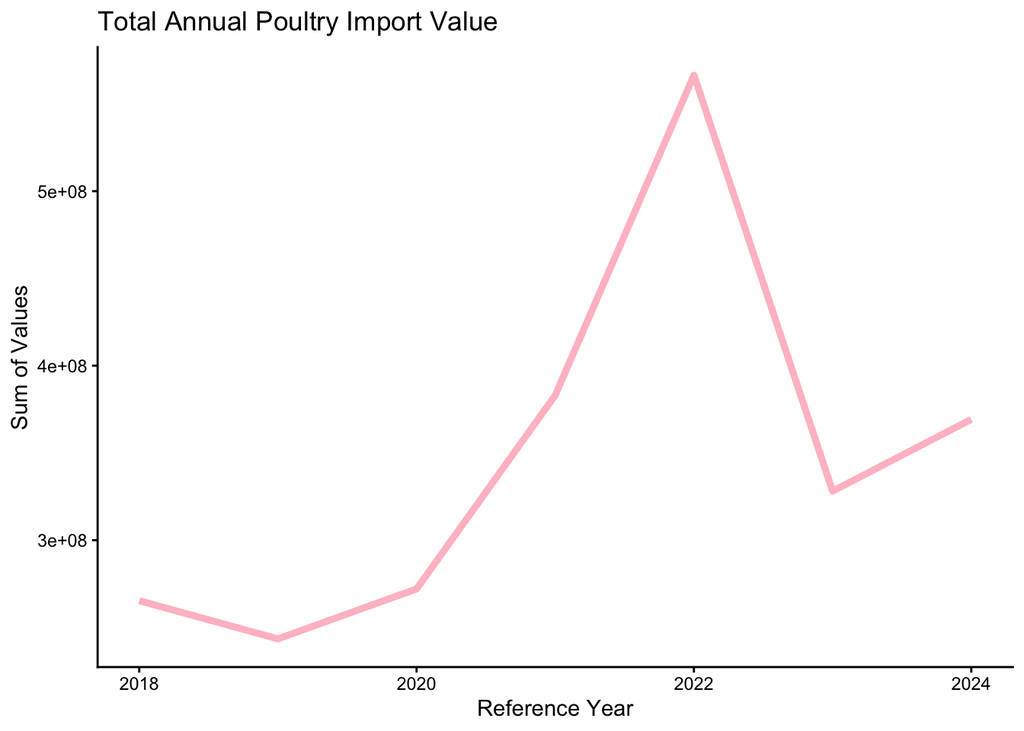

```r
#x = ref_year
#y = sum_primary_values_import

ggplot(data = sum_import_annual,
       mapping = aes(x=ref_year,
                     y=sum_primary_values_import)) +
  geom_line(linewidth = 1.6, color="pink")+
  theme_classic()+
  labs(
    x = "Reference Year",
    y = "Sum of Values",
    title = "Total Annual Poultry Import Value"
  )
```

## Exports:

#### 7. How many distinct countries were there (based on given data), to where US was exporting the poultry products?

```r
distinct_export_countries <- summarize (exports_poultrydata,
                                        Export_Countries = n_distinct(partner_desc)
)

print(distinct_export_countries)
```

```
# A tibble: 1 × 1
  Export_Countries
             <int>
1              188
```

**The U.S. exported poultry to 188 distinct nations over the years 2018 to 2024**

#### 8. What are the minimum, maximum trade values for exports? Mention the country, year and its respective value.

```r
min_max_exports <- filter (exports_poultrydata,
                           primary_value == min (primary_value, na.rm=TRUE)|
                           primary_value == max (primary_value, na.rm=TRUE)
                           )

print(min_max_exports)
```

```
# A tibble: 2 × 5
  ref_year flow_desc partner_desc qty_in_Mg primary_value
     <dbl> <chr>     <chr>            <dbl>         <dbl>
1     2018 Export    Czechia              4          2900
2     2024 Export    Mexico          852904    1172550687
```

**The Maximum Export was to Mexico in 2024 with a value of 1,172,550,687. The Minimum Export was to Czechia in 2018 with only 2,900 export value.**

#### 9. Identify the top 5 countries to which the USA exported the most (qty) in the years 2018 and 2024. List the countries and their corresponding export values.

```r
top5_export_countries2018 <- exports_poultrydata %>%
  filter(ref_year == 2018) %>%
  slice_max(qty_in_Mg, n=5)

print(top5_export_countries2018)
```

```
# A tibble: 5 × 5
  ref_year flow_desc partner_desc         qty_in_Mg primary_value
     <dbl> <chr>     <chr>                    <dbl>         <dbl>
1     2018 Export    Mexico                  792813     763541266
2     2018 Export    China, Hong Kong SAR    291713     412669749
3     2018 Export    Angola                  209389     183671360
4     2018 Export    Other Asia, nes         202493     188024792
5     2018 Export    Cuba                    195235     154537803
```

**The top 5 Export countries in 2018 were Mexico (792,813 Mg), China, Hong Kong (291,713 Mg), Angola (209,389 Mg), Other Asia, nes (202,493 Mg), and Cuba (195,235 Mg).**

```r
top5_export_countries2024 <- exports_poultrydata %>%
  filter(ref_year == 2024) %>%
  slice_max(qty_in_Mg, n=5)

print(top5_export_countries2024)
```

```
# A tibble: 5 × 5
  ref_year flow_desc partner_desc    qty_in_Mg primary_value
     <dbl> <chr>     <chr>               <dbl>         <dbl>
1     2024 Export    Mexico             852904    1172550687
2     2024 Export    Cuba               239643     298231173
3     2024 Export    Other Asia, nes    210049     261812562
4     2024 Export    Philippines        163084     187724475
5     2024 Export    Canada             148189     403487221
```

**The top 5 Export countries in 2024 were Mexico (852,904 Mg), Cuba (239,643 Mg), Other Asia, nes (210,049 Mg), Philippines (163,084 Mg), and Canada (148,189 Mg).**

#### 10. Calculate the total export value for the USA from each country. Which country had the highest total import value **from** US, and what was that value?

```r
sum_export_countries <- exports_poultrydata %>%
  group_by(partner_desc) %>%
  summarize(sum_primary_values = sum(primary_value))%>%
  arrange(desc(sum_primary_values)) #if you don't put this line, it will arrage alphabetically rather than from maximum to minimum.

print(sum_export_countries)
```

```
# A tibble: 188 × 2
   partner_desc         sum_primary_values
   <chr>                             <dbl>
 1 Mexico                       6823047519
 2 China                        3813940305
 3 Canada                       2227869347
 4 Other Asia, nes              1674974582
 5 Cuba                         1635093053
 6 China, Hong Kong SAR         1143876295
 7 Angola                       1028925256
 8 Guatemala                    1004824791
 9 Philippines                   978700870
10 Viet Nam                      869091874
# ℹ 178 more rows
```

**The country with the highest imports from the U.S. across these years was Mexico, with a total value of 6,823,047,519.**

#### 11. Calculate the total export value for the USA in each year from 2018 to 2025. Which year had the highest total export value, and what was that value?

```r
sum_export_annual <- exports_poultrydata %>%
  group_by(ref_year) %>%
  summarize(sum_primary_values_export = sum(primary_value)) %>%
  arrange(desc(sum_primary_values_export))

print(sum_export_annual)
```

```
# A tibble: 7 × 2
  ref_year sum_primary_values_export
     <dbl>                     <dbl>
1     2022                5401343250
2     2023                4886389111
3     2021                4772894502
4     2024                4766297796
5     2020                3837181558
6     2019                3749261464
7     2018                3628826731
```

**The year with the highest exports from the U.S. was 2022, with a total value of 5,401,343,250.**

#### 12. Plot a line graph showing the total annual export value for the USA from 2018 to 2024. Describe any noticeable trends or patterns (e.g., increases, decreases, or fluctuations) in the graph. Create a publication ready plot.

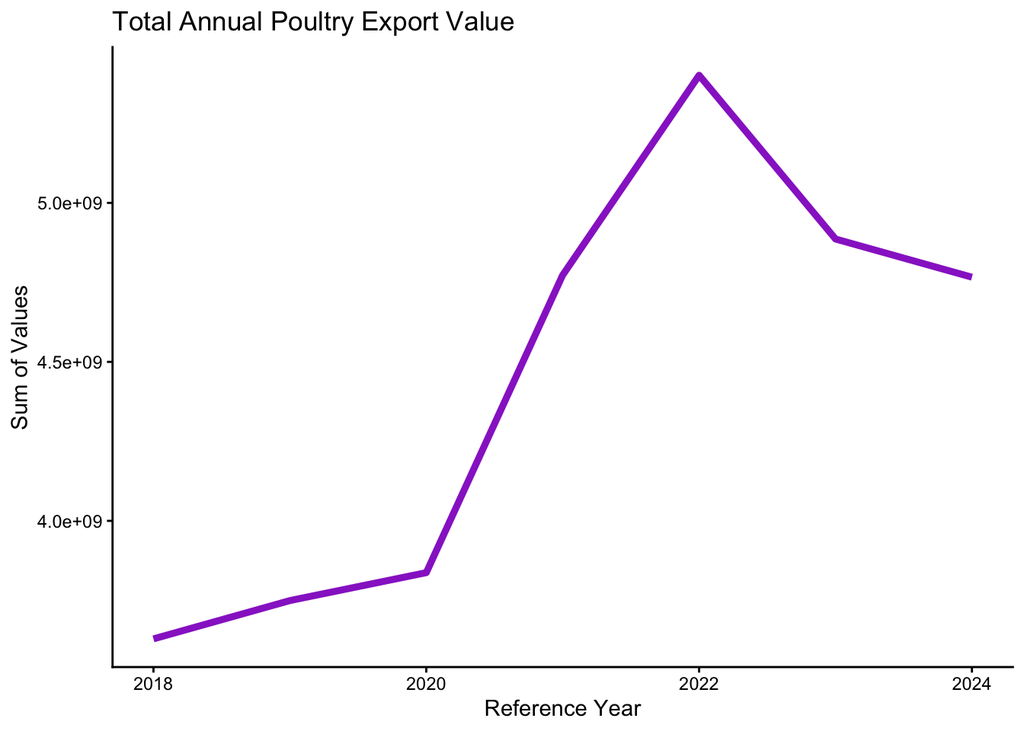

```r
#x = ref_year
#y = sum_primary_values_export

ggplot(data = sum_export_annual,
       mapping = aes(x=ref_year,
                     y=sum_primary_values_export)) +
  geom_line(linewidth = 1.6, color="darkorchid")+
  theme_classic()+
  labs(
    x = "Reference Year",
    y = "Sum of Values",
    title = "Total Annual Poultry Export Value"
  )
```

**The total Annual Export value for poultry from the U.S. shows an increase in exports from 2018 to 2022, 2022 being the peak export year. However, there is a gradual decrease for the following two years. When compared to the Import graph above, this suggests that Poultry trade generally reduced following 2022.**

## Imports - Exports Comparision:

#### 13. Does the U.S. behave more as a net importer or net exporter for this commodity? Explore it:

- Based on total value US imports and exports.

```r
sum_import_values <- sum(imports_poultrydata$primary_value)
print(sum_import_values)
```

```
[1] 2427597118
```

```r
sum_export_values <- sum(exports_poultrydata$primary_value)
print(sum_export_values)
```

```
[1] 31042194412
```

```r
Poultry_values <- data.frame(
  Total_Imports = sum_import_values,
  Total_Exports = sum_export_values
) %>%
  mutate ("Exports-Imports" = Total_Exports-Total_Imports)

print(Poultry_values)
```

```
  Total_Imports Total_Exports Exports-Imports
1    2427597118   31042194412     28614597294
```

**Considering the Total import value and export value across all years, the US is predominantly an exporter. The export value exceeds the import value by 28,614,597,294.**

- Based on number of countries US imports and exports

```r
distinct_import_countries #these are both tables because I used summarize earlier to make them.
```

```
# A tibble: 1 × 1
  Import_Countries
             <int>
1                7
```

```r
distinct_export_countries #so, I can pull their data while renaming the columns in data.frame using "pull"
```

```
# A tibble: 1 × 1
  Export_Countries
             <int>
1              188
```

```r
trade_partners <- data.frame(
  "Import Nations" = pull(distinct_import_countries),
  "Export Nations" = pull(distinct_export_countries)
) %>%
  mutate ("Exports-Imports" = pull(distinct_export_countries)-pull(distinct_import_countries))

print(trade_partners)
```

```
  Import.Nations Export.Nations Exports-Imports
1              7            188             181
```

**Based on the number of distinct countries the US traded with across all years, the US is predominantly an exporter for poultry products. There were only 7 importing nations, while the US exported to 188 nations.**

- Based on each year’s import export value.

```r
annual_sum_imports <- imports_poultrydata %>%
  group_by(ref_year) %>%
  summarize(sum_primary_values_import = sum(primary_value)) #This object is not arranged descending

print(annual_sum_imports)
```

```
# A tibble: 7 × 2
  ref_year sum_primary_values_import
     <dbl>                     <dbl>
1     2018                 265311797
2     2019                 243440897
3     2020                 272062857
4     2021                 383046235
5     2022                 566412591
6     2023                 328085936
7     2024                 369236805
```

```r
annual_sum_exports <- exports_poultrydata %>%
  group_by(ref_year) %>%
  summarize(sum_primary_values_export = sum(primary_value)) #This object is not arranged descending

print(annual_sum_exports)
```

```
# A tibble: 7 × 2
  ref_year sum_primary_values_export
     <dbl>                     <dbl>
1     2018                3628826731
2     2019                3749261464
3     2020                3837181558
4     2021                4772894502
5     2022                5401343250
6     2023                4886389111
7     2024                4766297796
```

```r
annual_import_export_value <- annual_sum_imports %>%
  full_join(annual_sum_exports, by = "ref_year") %>%
  mutate("Exports-Imports" = sum_primary_values_export - sum_primary_values_import) %>%
  arrange(ref_year)

annual_import_export_value
```

```
# A tibble: 7 × 4
  ref_year sum_primary_values_import sum_primary_values_export `Exports-Imports`
     <dbl>                     <dbl>                     <dbl>             <dbl>
1     2018                 265311797                3628826731        3363514934
2     2019                 243440897                3749261464        3505820567
3     2020                 272062857                3837181558        3565118701
4     2021                 383046235                4772894502        4389848267
5     2022                 566412591                5401343250        4834930659
6     2023                 328085936                4886389111        4558303175
7     2024                 369236805                4766297796        4397060991
```

**Based on total import export value from 2018-2024, the US was predominantly an exporter, exporting around 3 to nearly 5 billion more than it was importing each year.**

#### 14. Are the main import partners also major export destinations? Explore it based on the total import export value by countries.

Top 7 total Imports by Country

```r
Tot_Imports_by_Country <- imports_poultrydata %>%
  group_by(partner_desc) %>%
  summarize(sum_primary_values_import = sum(primary_value)) %>%
  arrange(desc(sum_primary_values_import))

print(Tot_Imports_by_Country)
```

```
# A tibble: 7 × 2
  partner_desc sum_primary_values_import
  <chr>                            <dbl>
1 Chile                       1532686723
2 Canada                       877439908
3 Israel                        13042397
4 Mexico                         4111455
5 Germany                         206221
6 China                           106106
7 Poland                            4308
```

Top 7 Total Exports by Country

```r
Tot_Exports_by_Country <- exports_poultrydata %>%
  group_by(partner_desc) %>%
  summarize(sum_primary_values_export = sum(primary_value)) %>%
  slice_max(sum_primary_values_export, n=7) %>%
  arrange(desc(sum_primary_values_export))

print(Tot_Exports_by_Country)
```

```
# A tibble: 7 × 2
  partner_desc         sum_primary_values_export
  <chr>                                    <dbl>
1 Mexico                              6823047519
2 China                               3813940305
3 Canada                              2227869347
4 Other Asia, nes                     1674974582
5 Cuba                                1635093053
6 China, Hong Kong SAR                1143876295
7 Angola                              1028925256
```

Comparing

```r
common_countries <-intersect(
  pull(Tot_Imports_by_Country, partner_desc),
  pull(Tot_Exports_by_Country, partner_desc)
)

print(common_countries)
```

```
[1] "Canada" "Mexico" "China"
```

**Since there are only 7 nations the US imported from across these years, I sorted the totals by country for these 7, and then created a top 7 Total Exports analysis by country. Then I compared if there is overlap for these countries across the lists using the intersect function, pulling the data in the two columns for trade partners in each of the created tables. The only nations that existed on both lists are Canada, Mexico, and China.**

#### 15. Can you calculate if US is in trade surplus or trade deficit for each year from 2018-2024?

```r
annual_deficit <- annual_sum_imports %>%
  full_join(annual_sum_exports, by = "ref_year") %>%
  mutate("Imports-Exports" = sum_primary_values_import - sum_primary_values_export) %>%
  mutate(
    "Trade" = case_when(
             "Imports-Exports">0 ~ "Surplus",
             "Imports-Exports"<0 ~ "Deficit" )) %>%
  arrange(ref_year)

print(annual_deficit)
```

```
# A tibble: 7 × 5
  ref_year sum_primary_values_i…¹ sum_primary_values_e…² `Imports-Exports` Trade
     <dbl>                  <dbl>                  <dbl>             <dbl> <chr>
1     2018              265311797             3628826731       -3363514934 Surp…
2     2019              243440897             3749261464       -3505820567 Surp…
3     2020              272062857             3837181558       -3565118701 Surp…
4     2021              383046235             4772894502       -4389848267 Surp…
5     2022              566412591             5401343250       -4834930659 Surp…
6     2023              328085936             4886389111       -4558303175 Surp…
7     2024              369236805             4766297796       -4397060991 Surp…
# ℹ abbreviated names: ¹sum_primary_values_import, ²sum_primary_values_export
```

**For all years, the US is in a trade surplus, where it is exporting more than it is importing from other nations.**

# Submitting your work

Once you have developed all the code and answers, make sure to Render this quarto file.

**Notes on rendering**:

- Make sure to render your work and inspect how the final html look like.
- If it does not look professional for whatever reason, then fix the issue, re-render it, recheck.
- Only send me your work once your html file looks professional.
- Some potential issues you may encounter and how to fix them:
  - Some times your code may be creating a table output that is waaay to long and cumbersome to scroll through when rendered. If this is the case, make it more professional looking by using the `head()` function to only print the first handful of rows (instead of thousands of rows).
  - **DO NOT** delete the file’s heading levels (# and ##). They set up the proper heading 1 and 2 levels, and I use them to guide my grading.
  - There’s a total of **15 questions**. If you mess around with the heading levels and you get a different number of questions on the rendered version, fix it.
  - If a given chunk is also outputting warnings or messages, inhibit this behavior by changing the chunk options `message` and `warning` to `FALSE` (I’ll demo this in a moment).
  - If, after rendered, 2 lines of text are connected and you wish to “break line” between them, add 2 extra spaces after the first one (I’lld demo this in a moment).

After rendering, an .html file will be created on your `code` folder.

Rename this file to `03_assignment_LASTNAME.html`.

For ex., `03_assignment_Bastos.html`.

Submit the html file on eLC by Monday Feb 2nd 11:59 pm, **one week** from today.